# 1. An example from sociolinguistics

Theory

Authors

Affiliation

Thomas Brunner

Catholic University of Eichstätt-Ingolstadt

Vladimir Buskin

Catholic University of Eichstätt-Ingolstadt

## 1 Barbieri (2007): Older Men and Younger Women

### 1.1 Defining the variable

New quotatives in American English: *be like*, *go*, *be all*:

1. “*I was like* ‘well if it’s not leaking, I don’t care.’”
2. “Do you, I asked I was running out and I *go*, ‘you’re trying to deliver a pizza here?’”
3. “My sister’s *all* ‘excuse me would you mind if I gave you, if I want your autograph.’”

### 1.2 Reviewing previous research

- Previous results with regard to **age**: *Be like* is known to be preferred by **younger speakers**.
- Previous results with regard to **sex** are **inconclusive**.

### 1.3 Research question

> “The study aims to contribute to the investigation of the controversial question of the effect of **speaker’s age** and **sex** on quotative use in American English, focusing on the newer quotatives *be like*, *go*, *be all*” (Barbieri 2007: 26).

### 1.4 Data

- **Choice of corpus**: 450,000 words taken from the Conversation component of the *Longman Spoken and Written English Corpus* (all files where the age and gender of speakers were available), i.e., about 50 hours of casual conversation coded for speakers’ **age** and **sex**.
- **Data extraction**: All forms of *be like*, *be all*, *go*, *say* extracted using corpus linguistic software; data entered into spreadsheet software; word counts of texts added via Delphi program.

### 1.5 Presentation of Results

| Quotative | Age group | Male use (per 100,000 words) | Female use (per 100,000 words) |
| --- | --- | --- | --- |
| **say** | 16–26 | 115 | 149 |
|  | 27–40 | 101 | 117 |
|  | 41–54 | 55 | 214 |
|  | 55+ | 67 | 433 |
| **be like** | 16–26 | 32 | 329 |
|  | 27–40 | 66 | 25 |
|  | 41–54 | - | 1 |
|  | 55+ | - | 19 |
| **go** | 16–26 | 25 | 113 |
|  | 27–40 | 61 | 18 |
|  | 41–54 | - | 15 |
|  | 55+ | - | 7 |
| **be all** | 16–26 | 14 | 33 |

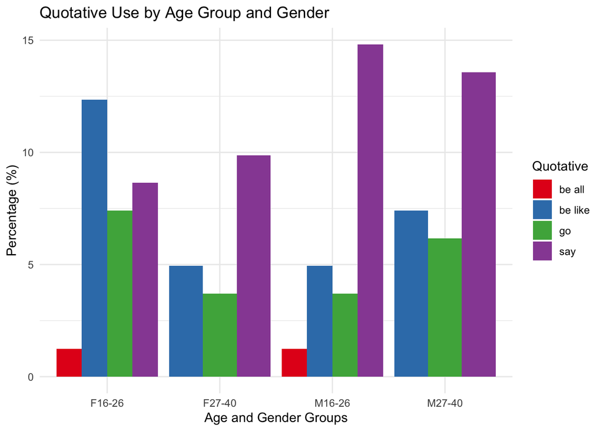

Reproduction of Barbieri’s Figure 5 ‘Proportional quotative use by men and women aged 16–26 and 27–40’

### 1.6 Formulation of results

> “In sum, the patterns of proportional use and the results of the statistical analyses show that there are striking differences in the way that men and women under the age of forty use quotative verbs. In contrast, in conforming to the traditional quotative *say*, men and women over forty displayed similar behavior” (Barbieri 2007: 38–39).

### 1.7 Some of her conclusions

> “In favoring *be like* over other quotatives, men in their late 20s and in their 30s display an ‘affinity’ with slightly younger women, women in their early 20s, rather than with women of their same age” (Barbieri 2007: 41).

## 2 Principles of Empirical Linguistics

- **Objectivity** — Independence from researchers or devices (→ replicability!)
- **Reliability** — Studies should be replicable.
- **Validity** — A study must actually address the problem formulated in the research question.

## 3 Exercises

**Exercise 1** As you read through the sections above, think about **what might go wrong** at each stage of the study!

**Exercise 2** Read another sociolinguistic study (e.g., Unuabonah and Gut 2018). As you read, identify similar key sections or “building blocks” used in this study (e.g., introduction, research question etc.). What purpose does each section serve in the study’s overall structure?

## References

Barbieri, Federica. 2007. “Older Men and Younger Women: A Corpus-Based Study of Quotative Use in American English.” *English World-Wide* 28 (1): 23–45. https://doi.org/10.1075/eww.28.1.03bar.

Unuabonah, Foluke Olayinka, and Ulrike Gut. 2018. “Commentary Pragmatic Markers in Nigerian English.” *English World-Wide* 39 (2): 190–213.